# SwiftKey Corpus Exploratory Analysis

Onna Nelson

March 2015

### Loading the data

Since Finnish and Russian use non-ASCII characters, we will need the unicode pacakge to handle this.

```r
library(Unicode)
```

Next, we set our working directories and load all the data. This is demonstrated for the English corpora, but can be preformed on the other languages as well.

```r
setwd("~/Desktop/SwiftKey Corpus/en_US")
en.tweets <- readLines("en_US.twitter.txt")
en.news <-  readLines("en_US.news.txt")
en.blogs <-  readLines("en_US.blogs.txt")
```

### Cleaning the data

My prediction algorithm will focus only on words, ignoring case, punctuation, and numbers. Although predicting capitalization, numbers, and punctuation (including emjoi), is interesting, this level of complexity will be reserved for later versions of the prediction algorithm. Therefore, it is necessary to get rid of numbers, extraneous spaces, and normalize the data to lowercase. This process will be demonstrated on the English blog data; however, the same process will be preformed on the twitter and news corpora as well. Getting rid of punctuation will cause contractions like *should’ve* to become separate single words, as in *should* and *ve*.

```r
en.blogs2 <- gsub("\\d","",en.blogs) #get rid of numbers
en.blogs3 <- gsub("\\W", " ", en.blogs2) #get rid of punctuation
en.blogs4 <- gsub("\\s+", " ", en.blogs3) #replace 2+ spaces with one
en.blogs5 <- tolower(en.blogs4) #make everything lowercase
```

In the interest of memory management, we’ll save this cleaned data set and clear the R console’s memory:

```r
saveRDS(en.blogs5, file="cleanEngBlogs.txt")
rm(list=ls(all=TRUE)) # clear data
clean.en.blogs <- readRDS("cleanEngBlogs.txt")
```

### Making unigram frequency tables

A unigram is a single word. Again, this process will be demonstrated on the English blog data; however, the same process was preformed on all twelve corpora.

```r
en.blogs6 <-strsplit(clean.en.blogs, "\\s") #split on spaces
en.blogs7 <-unlist(en.blogs6) #unlist the vector
en.blogs.freq <-table(en.blogs7) #makes a frequency list of every word
sorted.en.blogs.freq<-sort(en.blogs.freq, decreasing=T) #sort the frequency list
write.table(sorted.en.blogs.freq, "enBlogFreqs.csv",sep=",") #make a CSV file with the frequency list
```

Now that the unigram frequency data have been saved as a .csv file, we can return to this at a later point, without loading or manipulating the original data again. We can also clear the data and start with a fresh console.

```r
rm(list=ls(all=TRUE)) # clear data
setwd("~/Desktop/SwiftKey Corpus/en_US")
en.blog.unigram <- read.csv("enBlogFreqs.csv",col.names=c("word","blogFreq"))
en.news.unigram <- read.csv("enNewsFreqs.csv",col.names=c("word","newsFreq"))
en.tweet.unigram <- read.csv("enTweetFreqs.csv",col.names=c("word","tweetFreq"))
```

It is important to note that I named the words column as a generic “word”, but the frequency column has a unique name for each corpus. This will be important later on when merging the data.

### Making n-gram frequency tables

When predicting text, word order matters. We expect a native English speaker to frequently say *the red house* and almost never say *house red the*. Moreover, certain combinations of words (such as *the White House*) might be more common than others (such as *the red house*). An n-gram is a series of N number of words. The functions `ngram2` and `ngram3` will help produce these frequency lists.

```r
ngram2 <- function(corpus){
   ngrams <- vector()
   for(i in 1:length(corpus)){ #for each line
      temp <- unlist(strsplit(corpus[i], "\\W"))
      cat(i/length(corpus)*100, "%\n") #give progress
      for(j in 0:length(temp)){ #start at zero to include line beginning
         ngram <- c(temp[j],temp[j+1])
         ngrams <- append(ngram, ngrams)
         }
      }
   return(table(ngrams))
   }

ngram3 <- function(corpus){
   ngrams <- vector()
   for(i in 1:length(corpus)){ #for each line
      temp <- unlist(strsplit(corpus[i], "\\W"))
      cat(i/length(corpus)*100, "%\n") #give progress
      for(j in 0:length(temp)){ #start at zero to include line beginning
         ngram <- c(temp[j],temp[j+1],temp[j+2])
         ngrams <- append(ngram, ngrams)
         }
      }
   return(table(ngrams))
   }

ngram4 <- function(corpus){
   ngrams <- vector()
   for(i in 1:length(corpus)){ #for each line
      temp <- unlist(strsplit(corpus[i], "\\W"))
      cat(i/length(corpus)*100, "%\n") #give progress
      for(j in 0:length(temp)){ #start at zero to include line beginning
         ngram <- c(temp[j],temp[j+1],temp[j+2],temp[j+3])
         ngrams <- append(ngram, ngrams)
         }
      }
   return(table(ngrams))
   }
```

This process was highly inefficent.

### Exploring the Zipfian distribution

The number of rows tells us how many unique words are in the corpus (word **types**), while the sum of the freq column tells us how many total words are in the corpus (word **tokens**).

```r
blogTypes <- nrow(en.blog.unigram); blogTypes
```

```
## [1] 256889
```

```r
blogTokens <- sum(en.blog.unigram$blogFreq); blogTokens
```

```
## [1] 37975178
```

In the English blogs corpus, there are 256,889 unique word types, and a total of 37,975,178 word tokens. However, we cannot expect the average number of tokens for each word to be `blogTokens/blogTypes`. This is because language data tends to follow a **skewed distribution**.

According to Zipf’s Law (http://en.wikipedia.org/wiki/Zipf%27s_law), language data follows a logarithmic pattern. In other words, the most frequeny word (or n-gram) can be expected to be about twice as frequent as the second most frequent word (or n-gram), which in turn is twice as frequent as the third most frequent word (or n-gram), and so on. This means there are a small set of very highly frequent words and a large set of extremely infrequent words.

#### Common words

Moreover, the highly frequent words also overwhelmingly tend to be **function words** (pronouns, articles, prepositions, auxiliary verbs, and conjunctions) rather than **content words** (nouns, verbs, adverbs, and adjectives). Let’s look at the 10 most frequent words in the blogs corpus:

```r
head(en.blog.unigram,10)
```

```
##    word blogFreq
## 1   the  1860655
## 2   and  1094849
## 3    to  1069558
## 4     i   906685
## 5     a   903931
## 6    of   876836
## 7    in   598749
## 8    it   485362
## 9  that   484196
## 10   is   432763
```

```r
en.blog.unigram$blogFreq[1]/blogTokens * 100
```

```
## [1] 4.899661
```

```r
sum(en.blog.unigram$blogFreq[1:10])/blogTokens * 100
```

```
## [1] 22.94547
```

As expected, the 10 most frequent words in the blogs corpus are all function words: articles such as *the* and *a*, conjunctions such as *and*, prepositions such as *to*, *of*, *in*, pronouns such as *i*, *it*, and *that*, and the copula verb *is*. Moreover, these ten words make up 22.9% of all the tokens! Over a fifth of the blog corpus can be accounted for by just these ten words.

Similar results were found in the other corpora. Among tweets, the most common words are *the*, *i*, *to*, *a*, *you*, *and*, *for*, *it*, *in*, and *of*, which account for 16.9% of the twitter corpus. In the news corpus, the most common words are *the*, *to*, *a*, *and*, *of*, *in*, *s*, *that*, *for*, and *it*, which account for 21.8% of the news corpus.

It is important to note the differences between the three corpora. Tweets, which tend to be more social, contain the pronouns *I* and *you* more frequently than the other corpora. Words such as *of* and *that*, which are common in relative clauses and other syntactically complex phrases, are more common in the news and blogs corpora. The distributions of these words also differ from one corpus to the next. Therefore, it is important to consider context (news, blog, or tweet) when predicting text.

#### Unommon words

The least frequent words, which only occur once in a corpus, are known as hapaxes (http://en.wikipedia.org/wiki/Hapax_legomenon), and may make up as much as half of all the words in the corpus. For example, in a corpus of 1,000,000 unique words, up to 500,000 may be hapaxes.

```r
hapaxes <- en.blog.unigram$blogFreq==1; table(hapaxes)
```

```
## hapaxes
##  FALSE   TRUE
## 137910 118979
```

#### Visualizing the Zipfian distribution

One popular method of visualizing word frequency data is through a word cloud, which can be done in R using `library(wordcloud)`. This is demonstrated below for all three corpora:

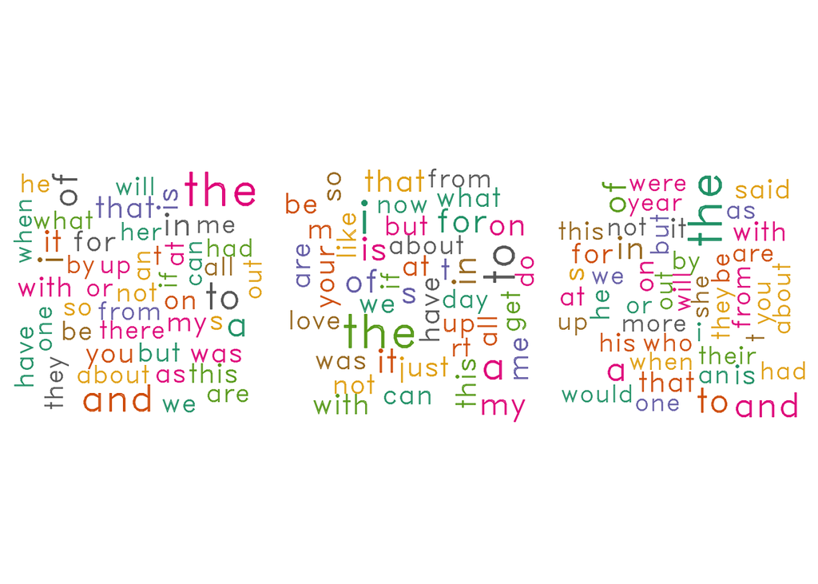

From left to right: blogs, tweets, and news. While visually appealing, these plots do not demonstrate any statistical information. The Zipfian distribution is better demonstrated by plotting the (logged) frequencies of each word against their ranked orders:

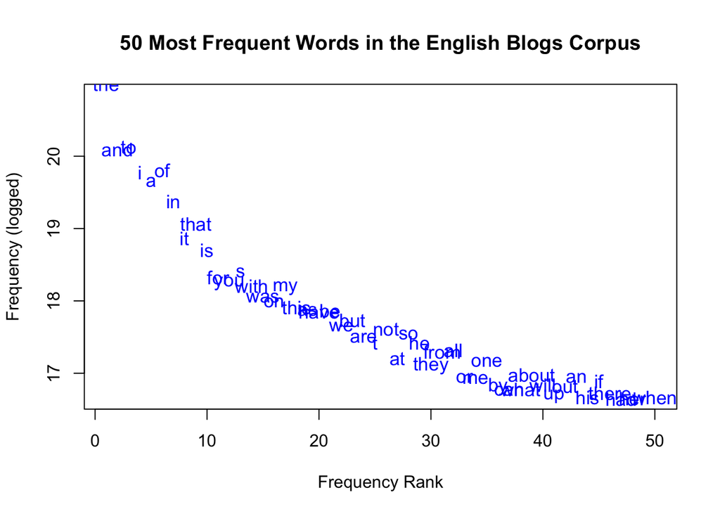

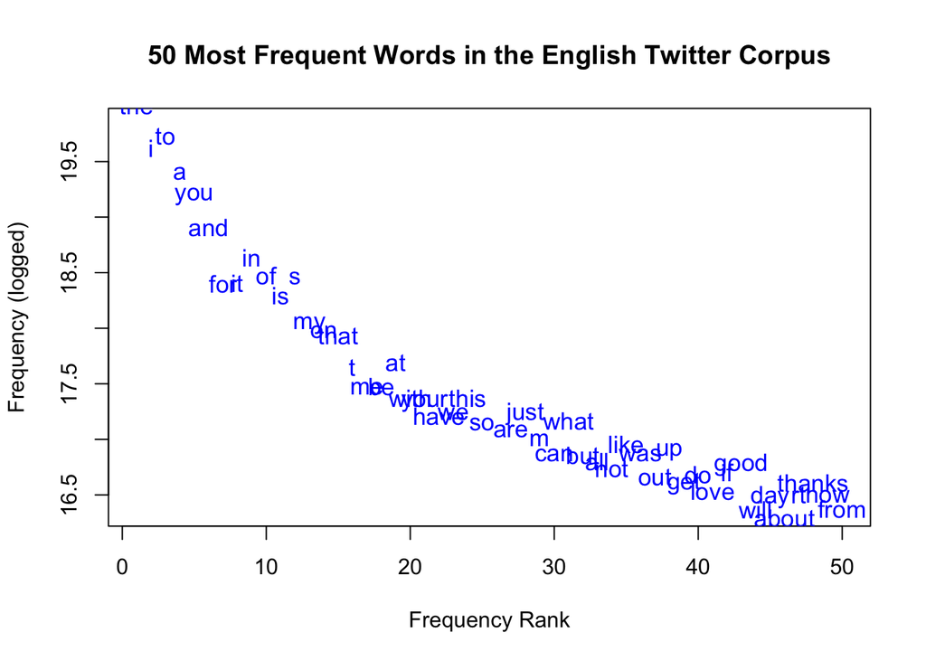

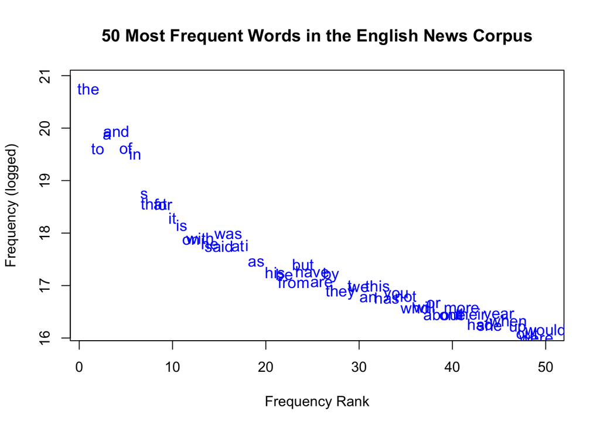

Here we can see the logarithmic curve predicted by Zipf’s Law. Again, we can see differences from one corpus to the next. While *the* is the most common word in all three, social words like *thanks* and question words like *what* are more common in the twitter corpus, due to its more interactive nature. Third person pronouns like *they* are more common in the news and blogs corpora, due to the fact that these may be more reportative.

```r
#blog2gram <- read.csv("enBlog2gramFreqs.csv",col.names=c("word","blog2gramFreq"))
#blog2gram <- blog2gram[ order(-blog2gramFreq), ]
#head(blog2gram)
```

### Plans for predicition

Unigram frequencies can help overall prediction. For example, given no other information, a highly frequent word such as *the* is much more likely to occur than an infrequent word like *botches*. However, raw frequencies alone will not be helpful in prediction. Therefore, the **relative frequencies** of each word will be used as factors in a machine learning predictive algorithm.

The most basic type of prediction would only use the relative frequency of unigrams. To add more complexity, and predictive power, we can also add 2-grams, 3-grams, or other n-grams as factors. To add even more predictive power, we can consider the context. For example, someone writing a tweet may be more likely to type *you* than someone writing a news article.

#### Merging the data

```r
English <- merge(en.tweet.unigram, merge(en.blog.unigram, en.news.unigram,all=T), all=T)
English[is.na(English)]=0 #makes NAs zero (common with hapaxes)
English$totalFreq <- English$tweetFreq+English$blogFreq+English$newsFreq
English <- English[ order(-English$totalFreq), ]
englishTypes <- nrow(English); englishTypes
```

```
## [1] 546645
```

```r
englishTokens <- sum(English$totalFreq); englishTokens
```

```
## [1] 103489549
```

```r
head(English, 10)
```

```
##        word tweetFreq blogFreq newsFreq totalFreq
## 265280  the    937889  1860655  1974508   4773052
## 270832   to    788925  1069558   906168   2764651
## 9117    and    438732  1094849   889538   2423119
## 316       a    617132   903931   894434   2415497
## 123620    i    918750   906685   195398   2020833
## 189296   of    359743   876836   774512   2011091
## 127621   in    380762   598749   679106   1658617
## 132831   it    383721   485362   286537   1155620
## 264903 that    271083   484196   371795   1127074
## 93743   for    385479   363928   353915   1103322
```

There are over half a million unique word types and over 100 million word tokens in this corpus!

#### Calculating relative frequencies

Raw numbers do not give an accurate picture of the data. Relative frequencies are more like probabilities, and can be used in a prediction model.

```r
tweetTokens <- sum(English$tweetFreq)
blogTokens <- sum(English$blogFreq)
newsTokens <- sum(English$newsFreq)

English$tweetRelFreq <- English$tweetFreq/tweetTokens
English$blogRelFreq <- English$blogFreq/blogTokens
English$newsRelFreq <- English$newsFreq/newsTokens
English$totalRelFreq <- English$totalFreq/englishTokens

head(English)
```

```
##        word tweetFreq blogFreq newsFreq totalFreq tweetRelFreq blogRelFreq
## 265280  the    937889  1860655  1974508   4773052   0.03053584  0.04899661
## 270832   to    788925  1069558   906168   2764651   0.02568586  0.02816466
## 9117    and    438732  1094849   889538   2423119   0.01428426  0.02883065
## 316       a    617132   903931   894434   2415497   0.02009262  0.02380321
## 123620    i    918750   906685   195398   2020833   0.02991271  0.02387573
## 189296   of    359743   876836   774512   2011091   0.01171253  0.02308971
##        newsRelFreq totalRelFreq
## 265280 0.056738731   0.04612110
## 270832 0.026039308   0.02671430
## 9117   0.025561435   0.02341414
## 316    0.025702124   0.02334049
## 123620 0.005614885   0.01952693
## 189296 0.022256090   0.01943279
```

### Future work

Future work will calculate relative frequencies for all the n-gram tables. All the n-gram frequencies will be merged with the unigram frequncies, such that any ngram or unigram contained in a 4-gram will appear as a single row. For example (fake data):

```r
example
```

```
##         [,1]      [,2]   [,3]     [,4]   [,5]     [,6]   [,7]     [,8]
## colname "4gram"   "freq" "3gram1" "freq" "3gram2" "freq" "2gram1" "freq"
## data    "A B C D" "0.01" "A B C"  "0.01" "B C D"  "0.01" "A B"    "0.01"
##         [,9]     [,10]  [,11]    [,12]  [,13]    [,14]  [,15]    [,16]
## colname "2gram2" "freq" "2gram3" "freq" "1gram1" "freq" "1gram2" "freq"
## data    "B C"    "0.01" "C D"    "0.01" "A"      "0.01" "B"      "0.01"
##         [,17]    [,18]  [,19]    [,20]
## colname "1gram3" "freq" "1gram4" "freq"
## data    "C"      "0.01" "D"      "0.01"
```

Hapaxes or extremely infrequent ngrams may be discarded, as they take up nearly half the data set and provide relatively little predictive power at a large memory cost.

The ultimate goal of the prediction algorithm will be to predict “D” given the sequence “A B C” and using the associated frequency probabilities.

Test cases will be generated.

### Bonus Word Clouds

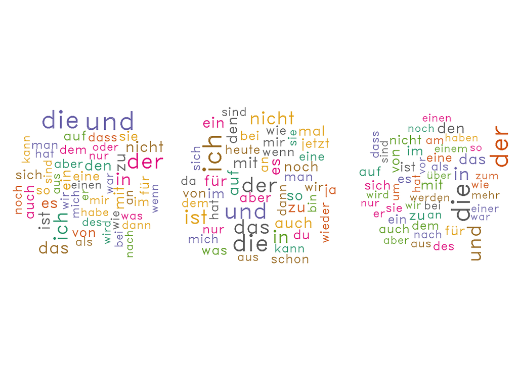

From left to right: blogs, tweets, and news.

Here we see some of the same trends from English: short function words like *die* and *der* “the”, *ich* “I”, and *ist* “is” stand out as the most common.

#### Finnish

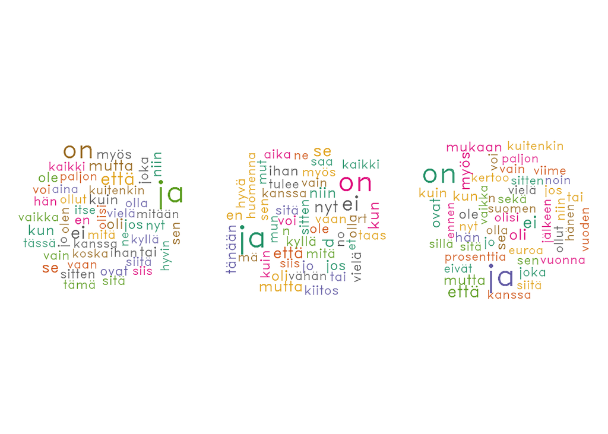

From left to right: blogs, tweets, and news.

Once again, we see small function words like *ja* “and”, *on* “there is”, and *ei* “not” which stand out as the most common in Finnish.

#### Russian

Getting Cyrllic fonts to work with `wordcloud()` would also be awesome for the Russian data! No luck yet; still exploring font packages!